# Visualization of Data

ML 14

12/3/2020

#### Datasets

The list below contains the list of datasets used for this visualization and their sources.

- Our world in Data (OWID, https://ourworldindata.org/coronavirus-data)
- Oxford Covid policy tracker (CGRT, https://github.com/OxCGRT/covid-policy-tracker)
- Apple mobility report (https://covid19.apple.com/mobility)
- Google mobility report (https://www.google.com/covid19/mobility/)

For simplicity this report focuses on the following countries:

- Germany
- Italy
- The Netherlands
- The United Kingdom
- France
- Austria

#### Variables of interest (Features and Labels)

The following variables of interest were extracted from each of the frames:

- OWID
  - “iso_code”
  - “continent”
  - “date”
  - “location”
  - “new_deaths”
  - “new_cases”
  - “new_tests”
  - “population”
  - “life_expectancy”
- CGRT
  - “C1_School.closing”,
  - “C2_Workplace.closing”
  - “C3_Cancel.public.events”
  - “C4_Restrictions.on.gatherings”
  - “C4_Restrictions.on.gatherings”
  - “C5_Close.public.transport”
  - “C6_Stay.at.home.requirements”
  - “C7_Restrictions.on.internal.movement”
  - “C8_International.travel.controls”
  - “H1_Public.information.campaigns”
  - “H6_Facial.Coverings”
  - “E1_Income.support”
- Apple mobility report
  - “transportation_type”
  - “value”
- Google mobility report
  - “retail_and_recreation_percent_change_from_baseline”
  - “grocery_and_pharmacy_percent_change_from_baseline”
  - “parks_percent_change_from_baseline”
  - “transit_stations_percent_change_from_baseline”
  - “workplaces_percent_change_from_baseline”
  - “residential_percent_change_from_baseline”

#### Visualization

##### OWID

The OWID data represents multiple time-series for all countries of interest on the variables of interest. Visualization of the “new_cases” series are depicted below.

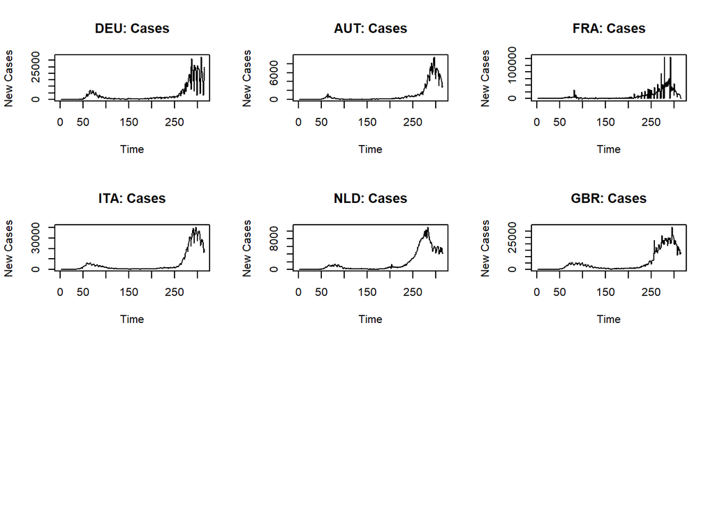

```r
# Plot time series for new_cases
par(mfrow=c(3,3))

for (iso in iso_codes) {
  iso_data <- owid$new_cases[owid$iso_code == iso]
  plot(1:length(iso_data),iso_data,
       type = "l",main=paste0(iso,": Cases"),
       ylab = "New Cases",xlab = "Time")
}
```

##### CGRT

From the CGRT we extract information on containment and closure policies (C1-C8), economic policies (E1), and health system policies (H1, H6). The print statements below list the column sum (over time) for each measure per country. (scales for variables can be found here: https://github.com/OxCGRT/covid-policy-tracker/blob/master/documentation/codebook.md#containment-and-closure-policies)

```r
# Print sum of interventions per type per country
for (country in country_names) {
  print(country)

  print(colSums(cgrt[cgrt$CountryName == country,
                     columns_of_interest_cgrt],
                na.rm = TRUE))
}
```

```
## [1] "Germany"
##                    C1_School.closing                 C2_Workplace.closing
##                                  505                                  506
##              C3_Cancel.public.events        C4_Restrictions.on.gatherings
##                                  540                                  987
##      C4_Restrictions.on.gatherings.1            C5_Close.public.transport
##                                  987                                    0
##         C6_Stay.at.home.requirements C7_Restrictions.on.internal.movement
##                                  161                                  405
##     C8_International.travel.controls      H1_Public.information.campaigns
##                                  853                                  603
##                  H6_Facial.Coverings                    E1_Income.support
##                                  481                                  518
## [1] "Austria"
##                    C1_School.closing                 C2_Workplace.closing
##                                  382                                  468
##              C3_Cancel.public.events        C4_Restrictions.on.gatherings
##                                  435                                  807
##      C4_Restrictions.on.gatherings.1            C5_Close.public.transport
##                                  807                                   88
##         C6_Stay.at.home.requirements C7_Restrictions.on.internal.movement
##                                  200                                  179
##     C8_International.travel.controls      H1_Public.information.campaigns
##                                  707                                  562
##                  H6_Facial.Coverings                    E1_Income.support
##                                  561                                  514
## [1] "France"
##                    C1_School.closing                 C2_Workplace.closing
##                                  507                                  549
##              C3_Cancel.public.events        C4_Restrictions.on.gatherings
##                                  455                                 1104
##      C4_Restrictions.on.gatherings.1            C5_Close.public.transport
##                                 1104                                   98
##         C6_Stay.at.home.requirements C7_Restrictions.on.internal.movement
##                                  242                                  371
##     C8_International.travel.controls      H1_Public.information.campaigns
##                                  777                                  624
##                  H6_Facial.Coverings                    E1_Income.support
##                                  676                                  520
## [1] "Italy"
```

[output cut: 23 more lines]

```
##                  H6_Facial.Coverings                    E1_Income.support
##                                  366                                  518
## [1] "United Kingdom"
##                    C1_School.closing                 C2_Workplace.closing
##                                 2807                                 2896
##              C3_Cancel.public.events        C4_Restrictions.on.gatherings
##                                 2571                                 5072
##      C4_Restrictions.on.gatherings.1            C5_Close.public.transport
##                                 5072                                 1280
##         C6_Stay.at.home.requirements C7_Restrictions.on.internal.movement
##                                 1449                                 1790
##     C8_International.travel.controls      H1_Public.information.campaigns
##                                 1785                                 3099
##                  H6_Facial.Coverings                    E1_Income.support
##                                 1421                                 2562
```

##### Apple mobility report

The Apple mobility report contains again time-series data, reflecting the change in percentage (a value of 100 reflects baseline) with regard to use of three different transportation types. Visualizations per country are depicted below.

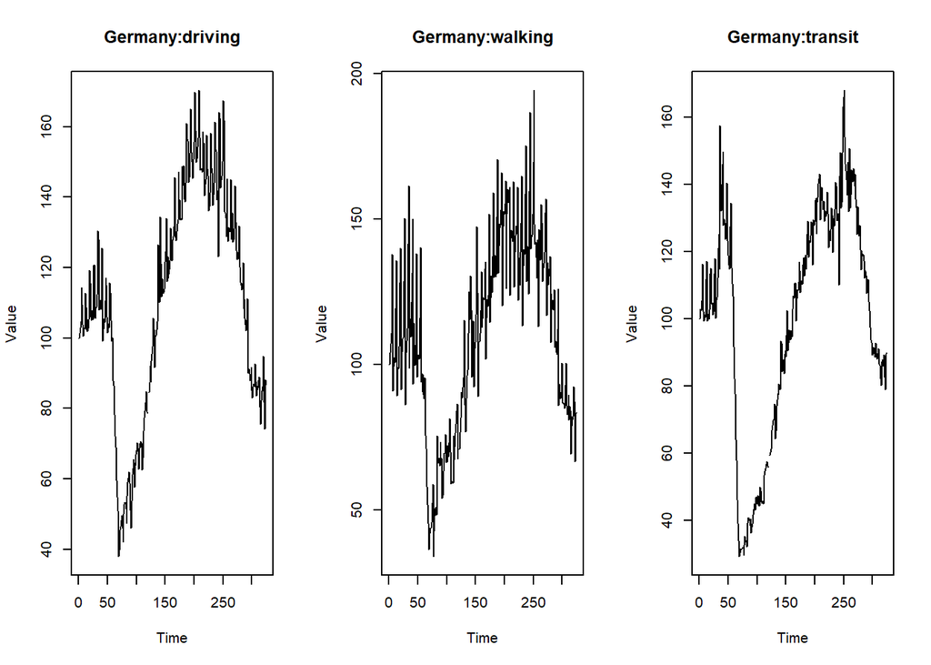

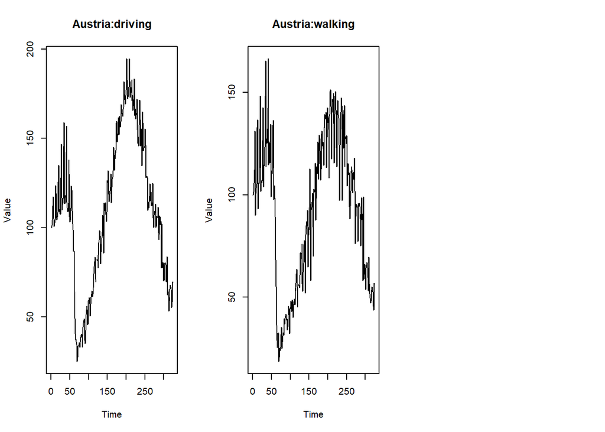

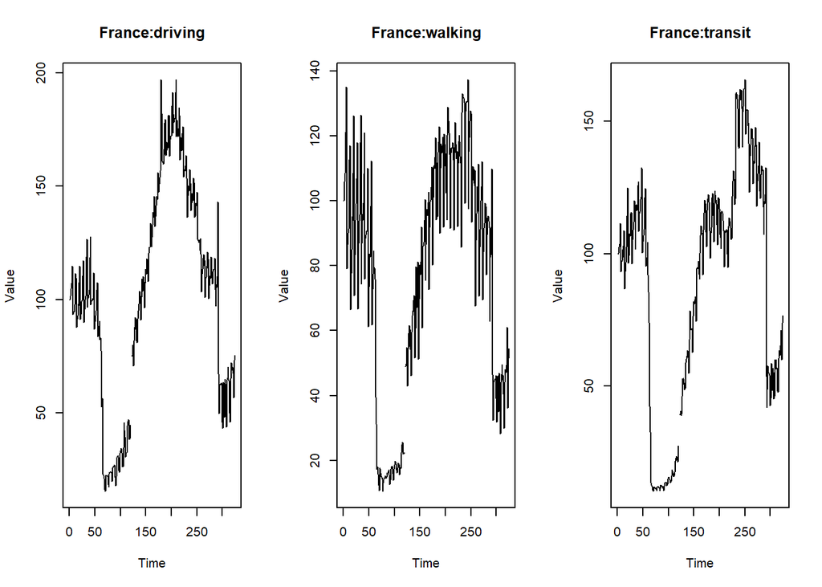

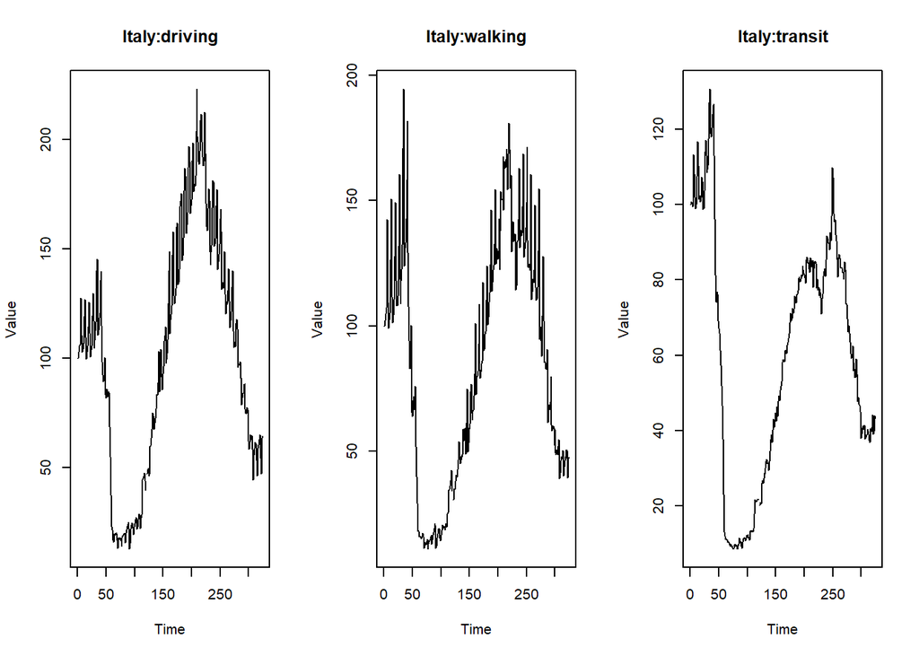

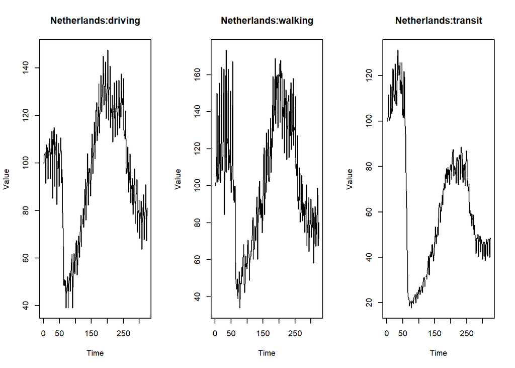

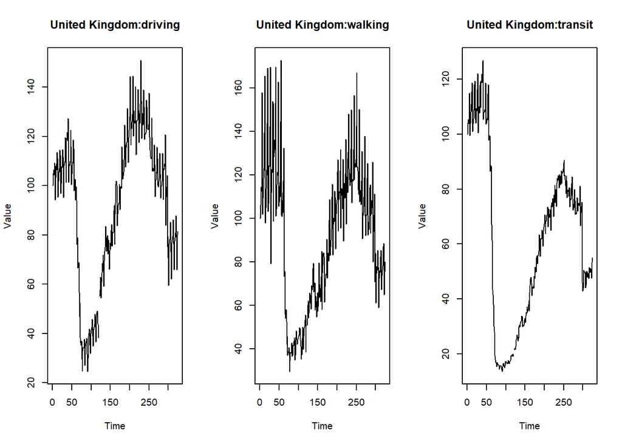

```r
# Plot mobility series per transport type from Apple

mobility_types = unique(mobility_apple$transportation_type)

for (country in country_names) {
  country_data <- mobility_apple[mobility_apple$region == country,]
  par(mfrow=c(1,3))
  for (mobility_type in mobility_types) {
    mobility_data <- country_data$value[country_data$transportation_type == mobility_type]
    if (length(mobility_data) > 1) {
      plot(country_data$value[country_data$transportation_type == mobility_type],
           type = "l",main = paste0(country, ":",mobility_type),
           ylab="Value",xlab = "Time")
    }
  }
}
```

##### Google mobility report

The Google mobility report contains again time-series data, reflecting the change in percentage (a value of 0 reflects baseline) with regard to the amount of traffic in six different type of areas. Visualizations per country are depicted below.

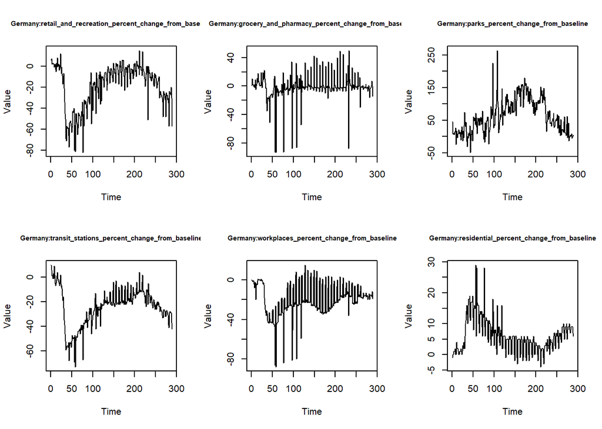

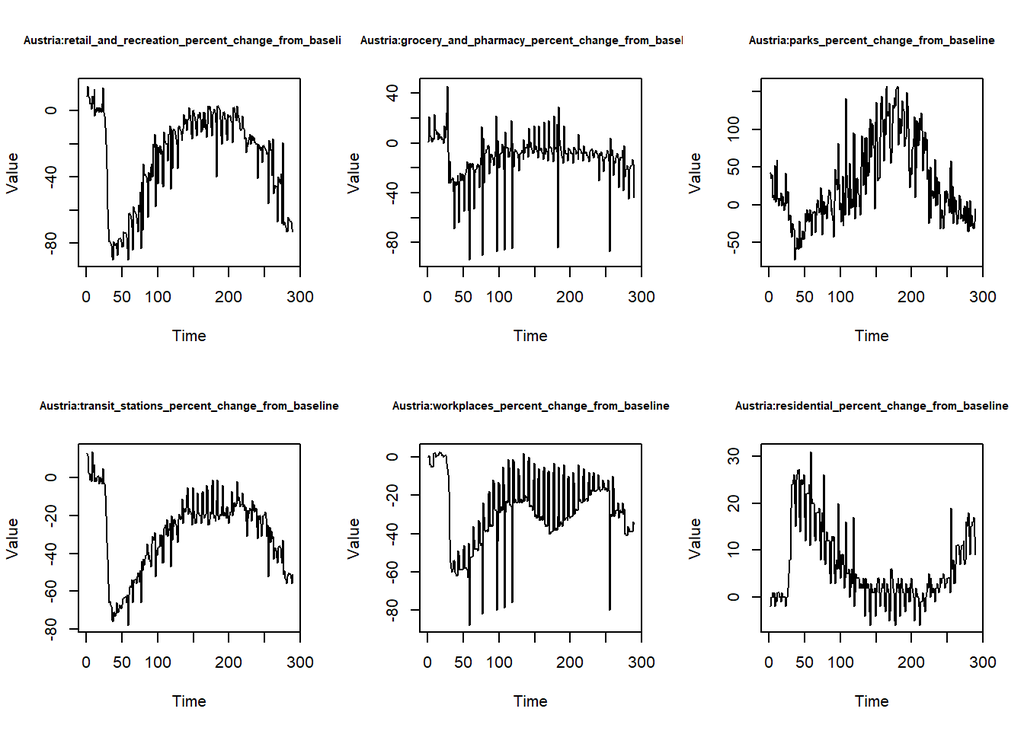

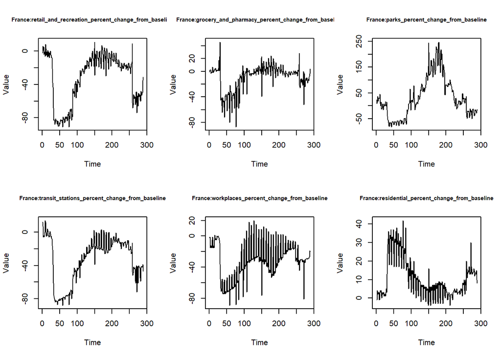

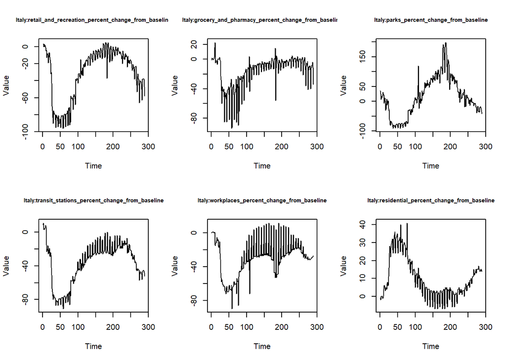

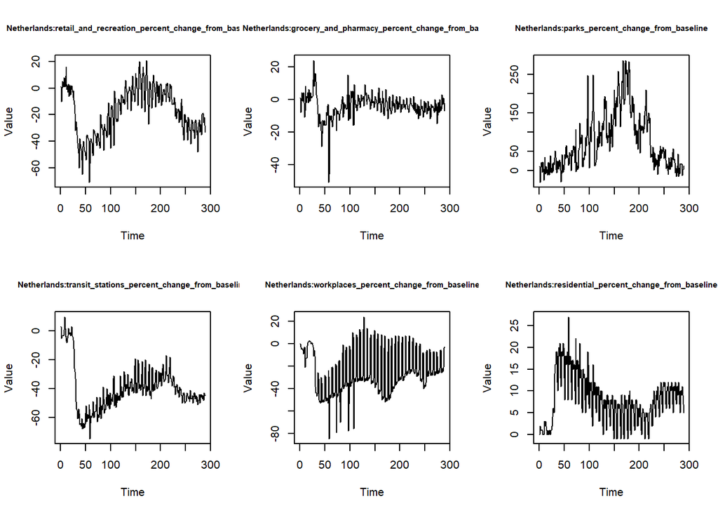

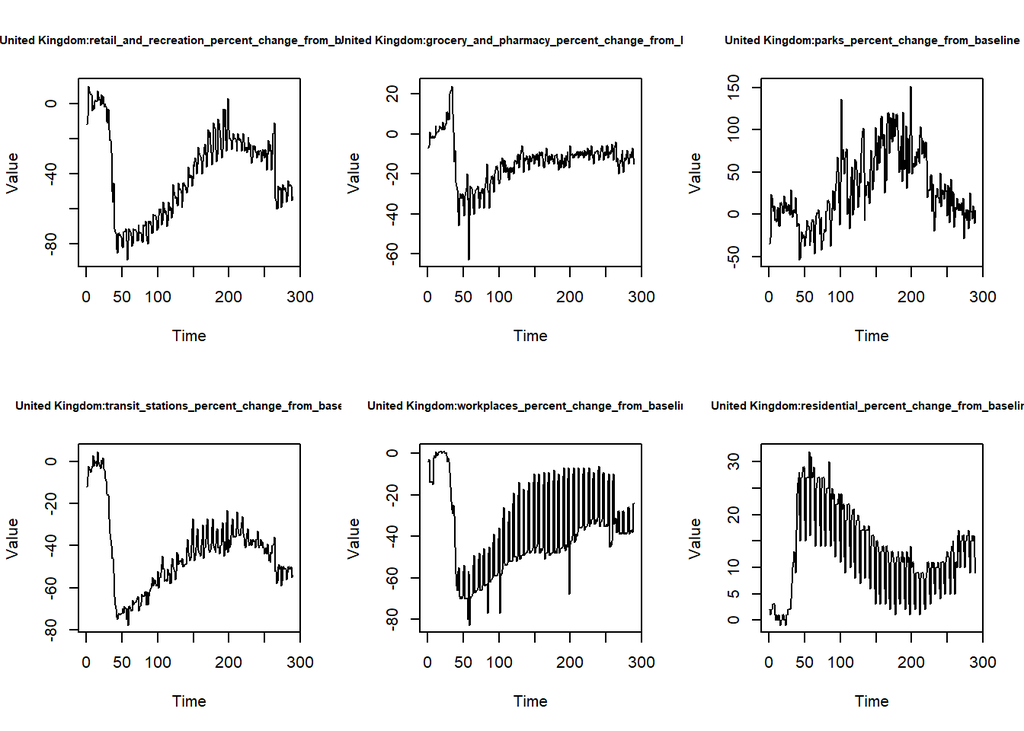

```r
# Plot mobility series per area type from Google
for (country in country_names) {
  country_data <- mobility_google[mobility_google$country_region==country,]
  par(mfrow=c(2,3))
  for (area in areas_of_interest) {
    area_data <- country_data[,area]
    if (length(area_data) > 0) {
      plot(area_data,
           type = "l",main = paste0(country, ":",area),
           ylab="Value",xlab = "Time",cex.main=0.7)
    }
  }
}
```